# Weekly Energy Charts

November 11, 2022

Sign up to receive our email updates via [Substack](https://leach.substack.com/)

[interactive chart not shown]

# Featured Stories

## US Carbon Offsets

#### [Marc Vermette](https://www.linkedin.com/in/marc-vermette/)

USA Climate Envoy John Kerry revealed a [carbon offset plan](https://www.protocol.com/bulletins/john-kerry-carbon-credits-cop27) that would allow corporations to fund renewable energy projects in developing countries that are struggling to transition away from fossil fuels.

This plan, to be released in the coming year, will create carbon offsets to reward investments in projects that help accelerate renewable energy projects in developing countries. Businesses can then buy these offsets to balance out some portion of their CO2 emissions.

However, voluntary carbon offset programs are [often criticized](https://www.washingtonpost.com/business/energy/what-are-carbon-offsets-and-how-many-really-work/2022/11/09/44f330c4-6079-11ed-a131-e900e4a6336b_story.html) for being insufficiently regulated, and for allowing governments and corporations to compromise net-zero emission goals.

Climate policy expert [Rachel Cleetus](https://www.ucsusa.org/about/people/rachel-cleetus) weighed in, arguing that a “voluntary carbon credit program” is “not [the] answer in a world already on fire, underwater and facing mounting climate losses and damage.”

[Original Article](https://www.cnbc.com/2022/11/09/us-launches-carbon-offset-program-to-help-developing-countries.html)

## Is the energy transition easier for the rich?

#### [Marc Vermette](https://www.linkedin.com/in/marc-vermette/)

Spending on clean energy is expected to reach a record $1.4 trillion in 2022, [according to the IEA](https://www.iea.org/data-and-statistics/charts/annual-clean-energy-investment-2017-2022).

However, this economic and environmental growth takes place primarily in richer countries with lower costs of financing new infrastructure.

[figure not shown]

Middle-income countries can spend upwards of twice as much paying off debt, as well as having a significantly harder time acquiring loans for projects like these.

The UN, consisting primarily of richer countries, previously promised to grant developing countries $100 billion annually in financing to cut their emissions and adapt to a hotter world. This promise [was broken](https://www.nature.com/articles/d41586-021-02846-3).

The [World Bank](https://www.worldbank.org/en/news/press-release/2022/11/03/countries-could-cut-emissions-by-70-by-2050-and-boost-resilience-with-annual-investments-of-1-4-of-gdp) determined that “contributing 1.4% of GDP annually could help to reduce emissions in developing countries by as much as 70% by 2050,” while also increasing their energy security.

[Original Article](https://www.dw.com/en/renewable-energy-transition-graphs/a-63674250)

## COP27 Update

#### [Erica Beattie](https://www.linkedin.com/in/erica-beattie-594b471a1)

World leaders are meeting in Sharm el Sheikh, Egypt, for [two weeks of climate negotiations](https://news.un.org/en/story/2022/10/1129947), set to end on November 18th. Oil and gas industry representatives joined the Canadian delegation, and their [presence has led to criticism](https://calgaryherald.com/commodities/energy/ruffing-some-feathers-at-cop27-canada-includes-oil-and-gas-companies-in-its-delegation/wcm/79b6e7de-7d3e-4c2a-a018-3bbfcfafe9bc).Environmental groups and climate activists are pointing out the irony of the situation: an industry responsible for large amounts of emissions taking part in an event dedicated to climate action. Industry argues that their participation is crucial, as collaboration with industry will help us meet Canada’s climate goals. Ideally, Canada’s oil gas industry will find ways to maintain its operations while reducing emissions, and end up as part of the climate crisis solution.

Later this week, a presentation by the Pathways Alliance, representing Canada’s six largest oilsands companies, will lay out the industry’s plan to reduce emissions. Some components of this plan include large investments in carbon-capture and storage projects, as well as other clean technologies.

Another dire issue looming over this year’s UN climate conference is the global energy crisis resulting from tight energy supplies and Russia’s invasion of Ukraine.

# Oil

## Weekly Crude Prices

### Feature Crude

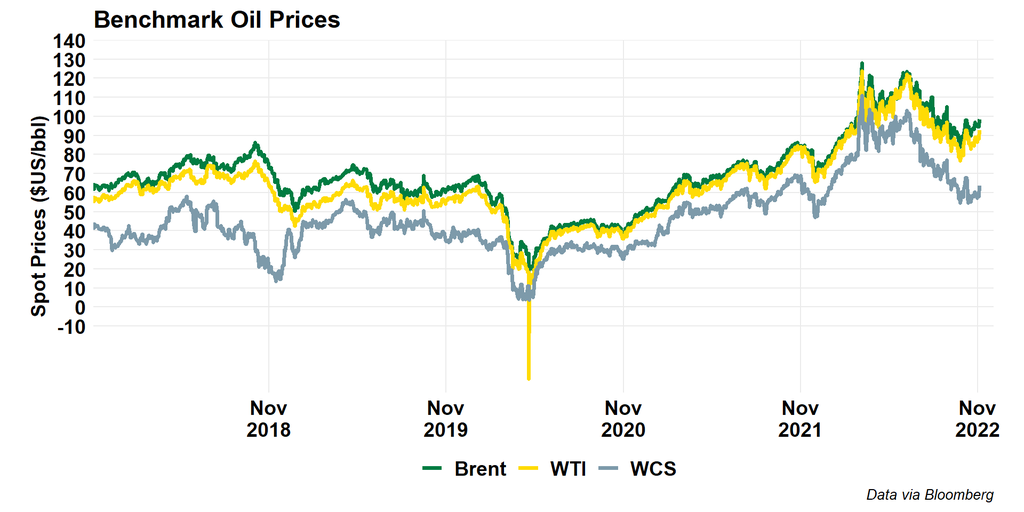

### Alberta Crude

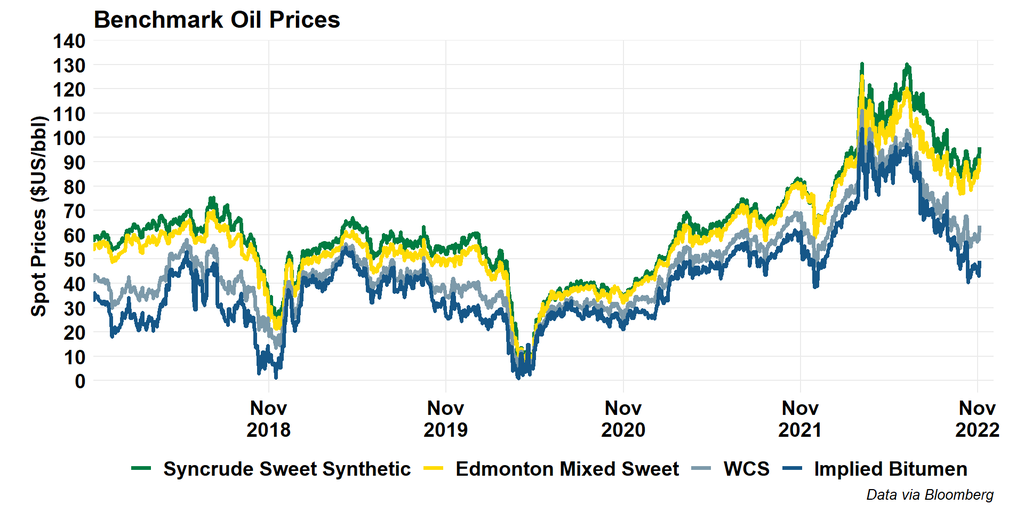

### Alberta Crude (Short)

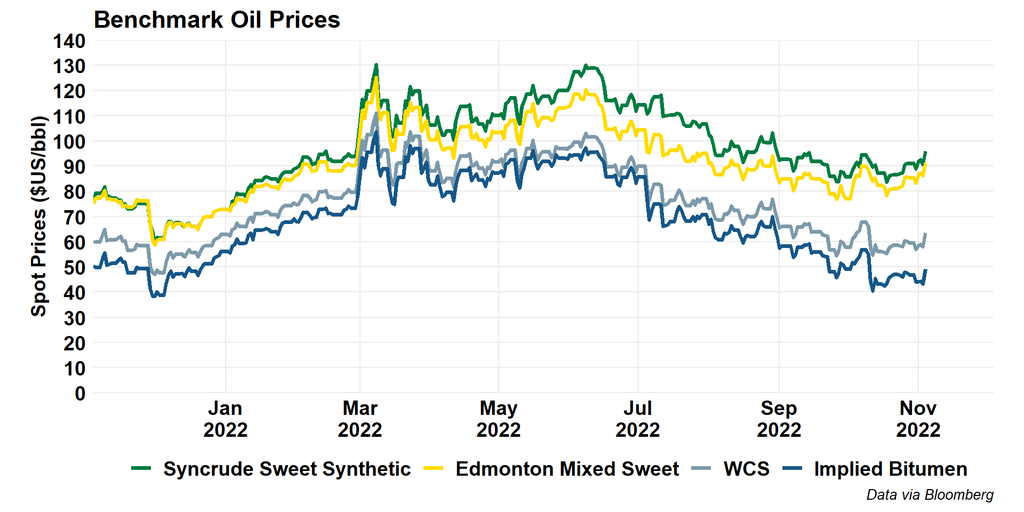

### US Crude

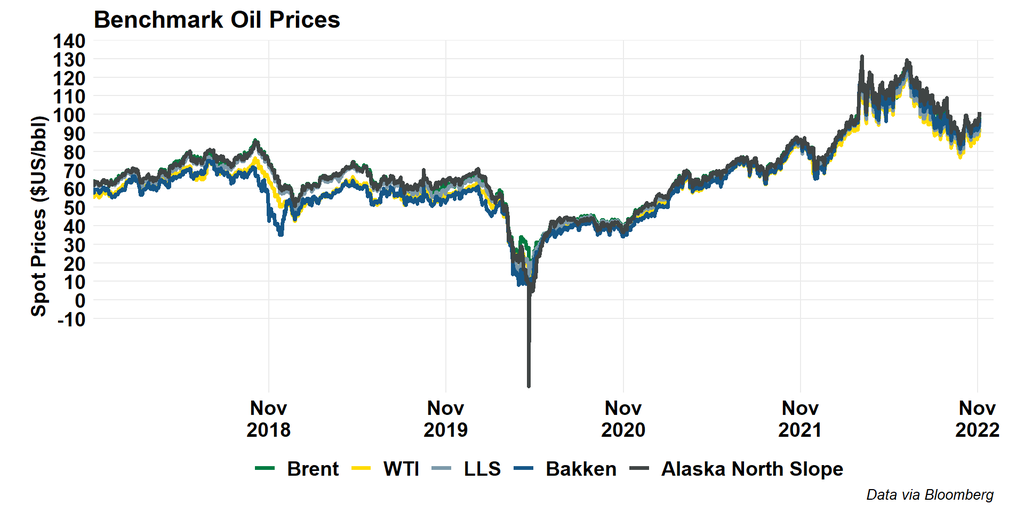

### Global Crude

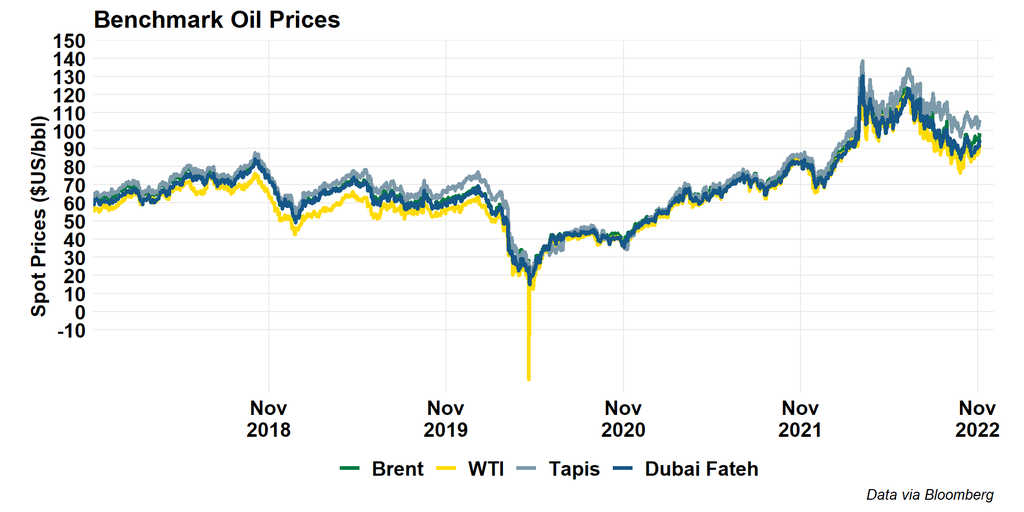

## Oil Price Differentials

### Brent-WTI

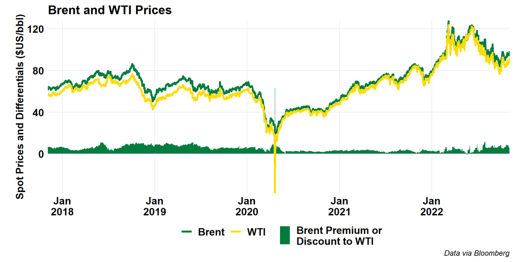

### WTI-WCS

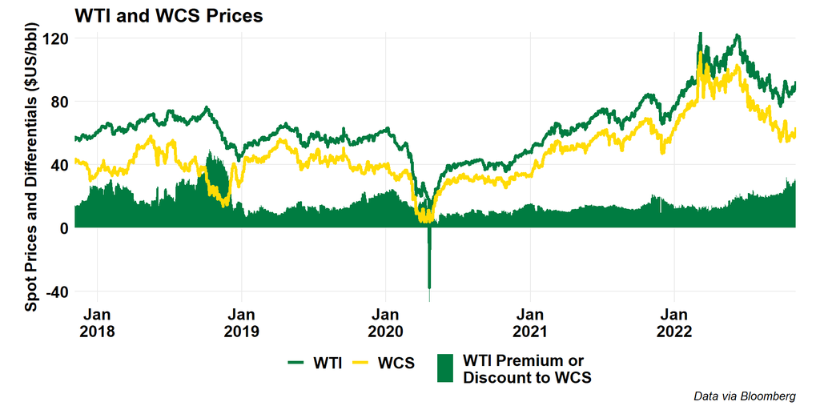

### WTI-WCS (Short)

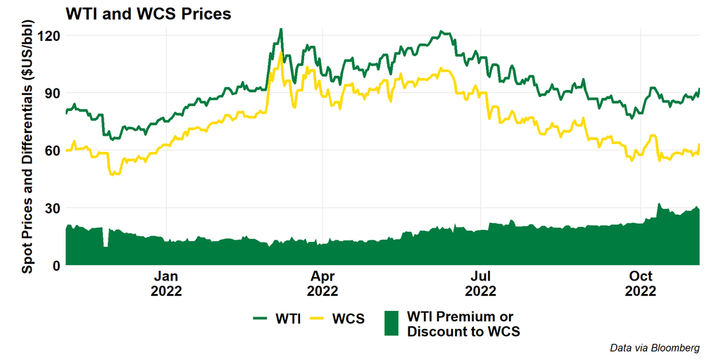

### Maya-WCS

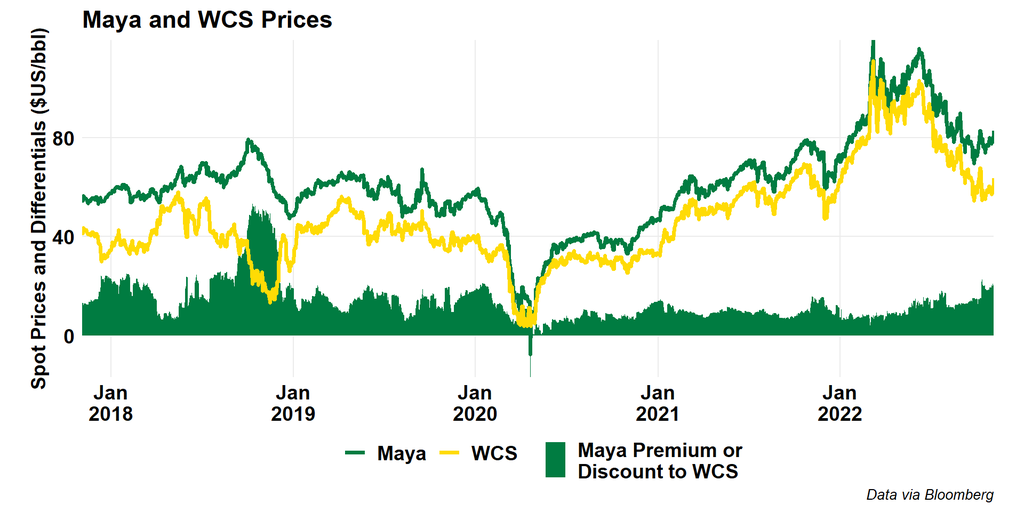

### WTI Cushing vs MEH

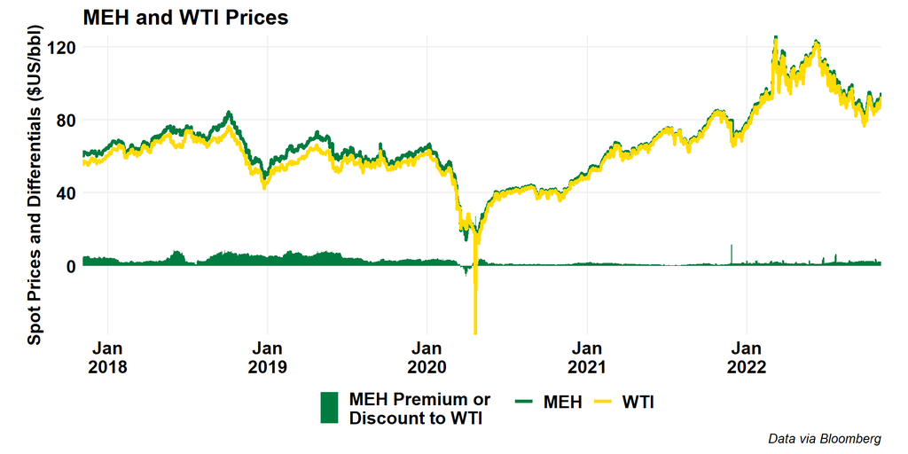

## Forward Curves

### WTI

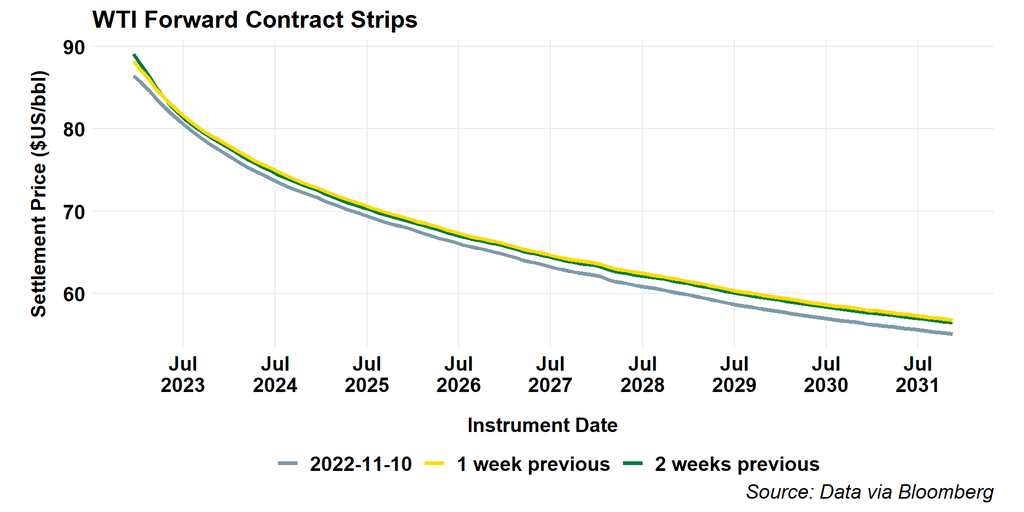

### Brent

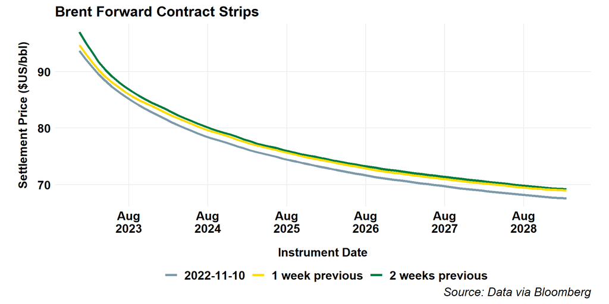

## Canadian Crude Supply and Disposition

### Canadian Production

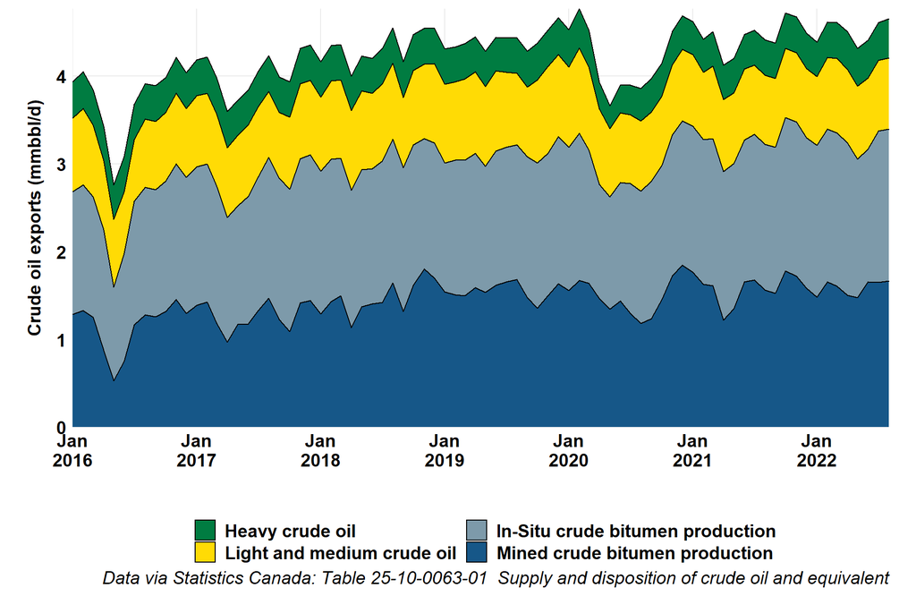

### Alberta Production

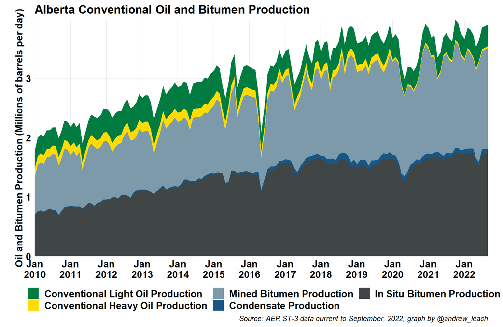

### Imports

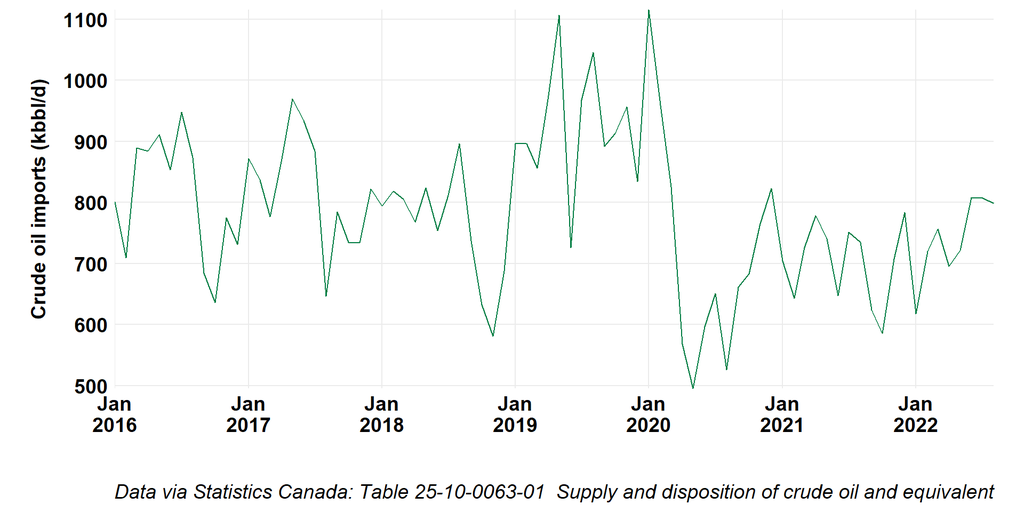

### Exports

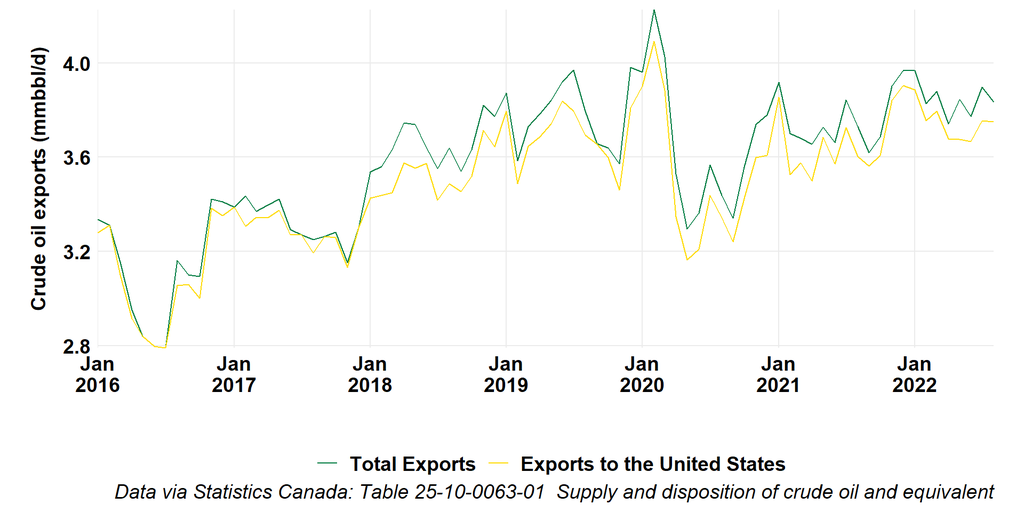

### Exports by Rail

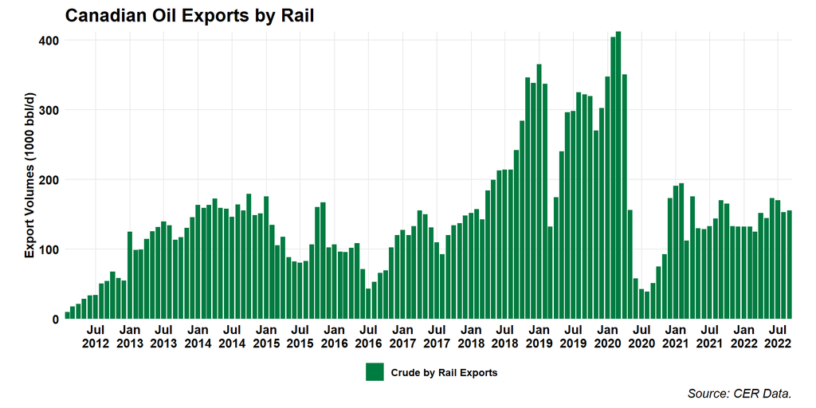

## US Oil

### Production

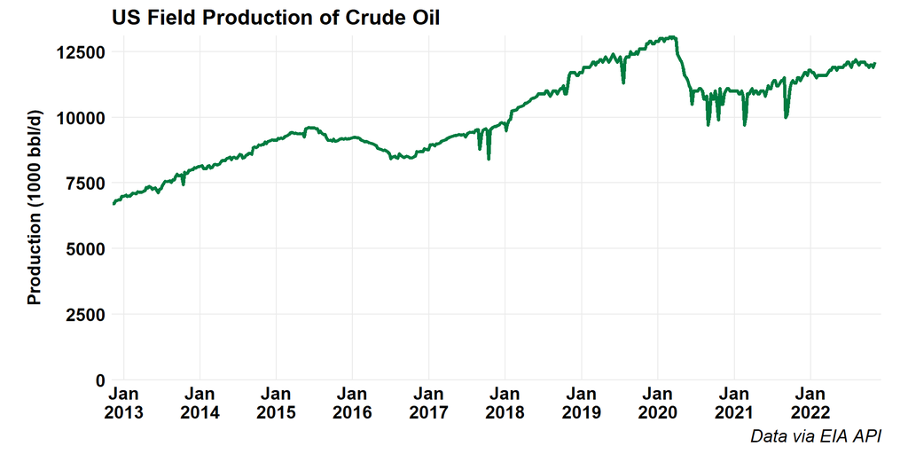

### LTO Production by Play

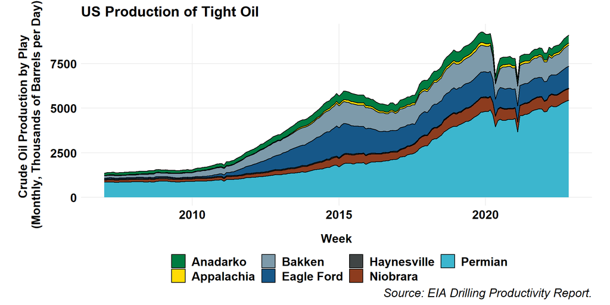

### Net Imports

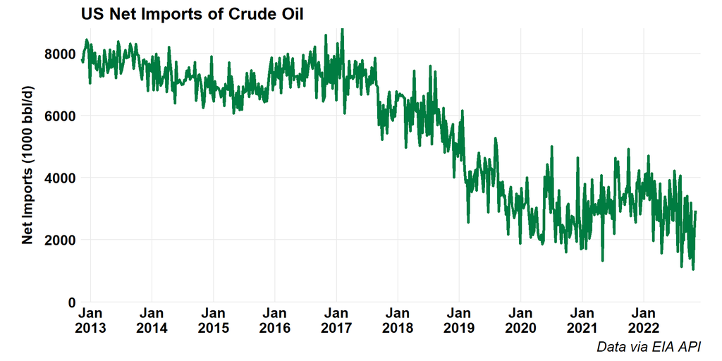

### Oil and Product Net Imports

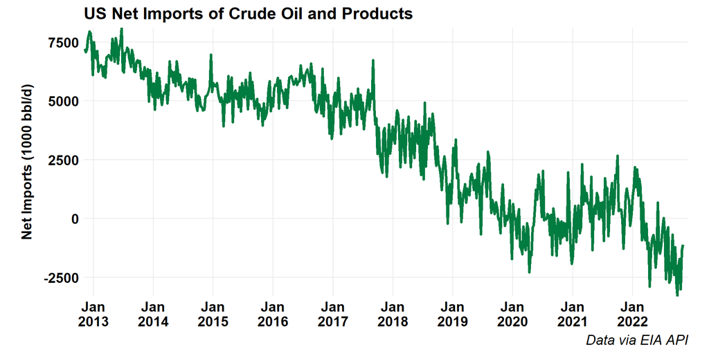

### Inventories

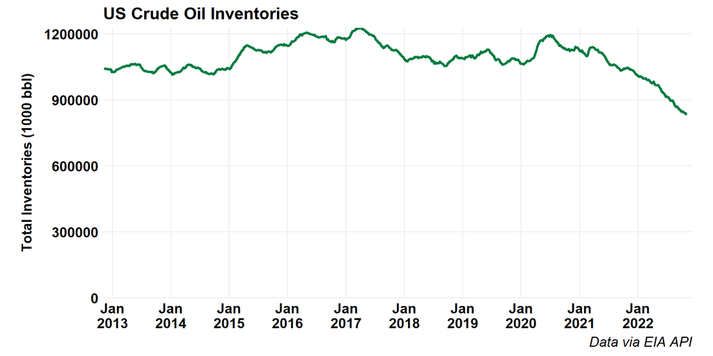

### EIA STEO Forecasts

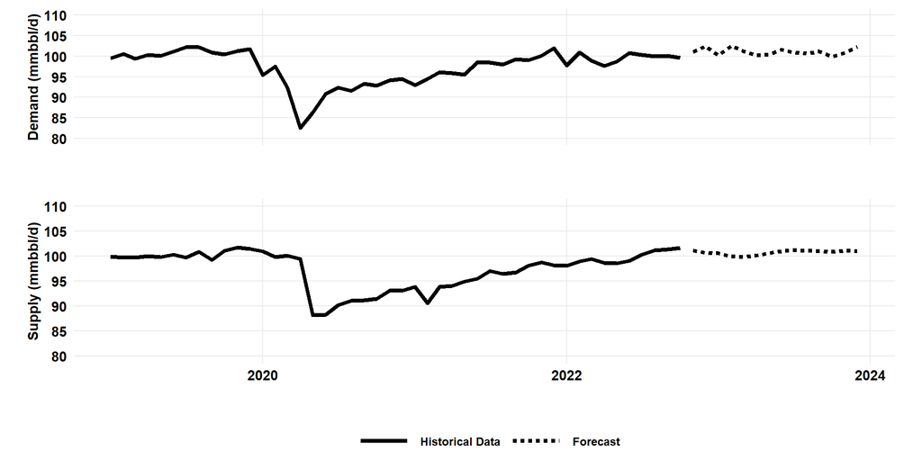

# Refined Products

## Canadian Gasoline Prices

### Map

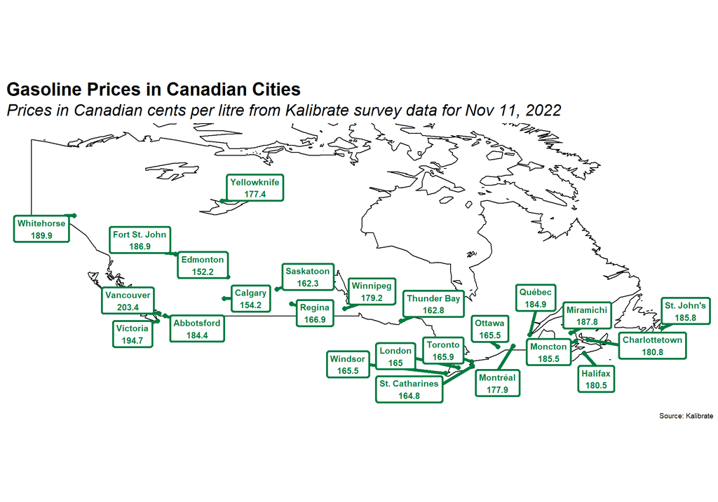

### Historic Gasoline Prices

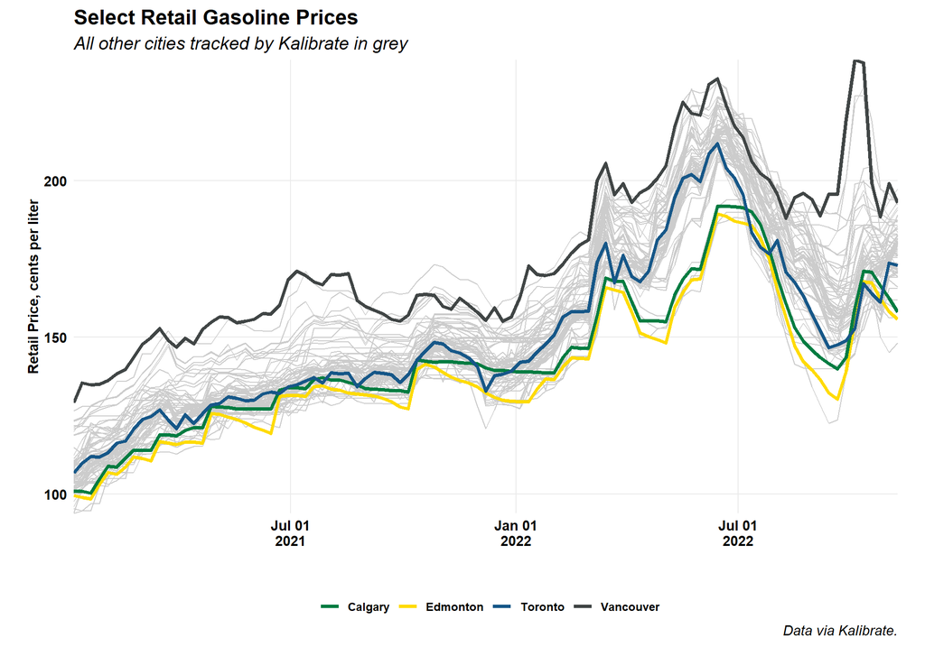

### Historic Gasoline Prices in BTC

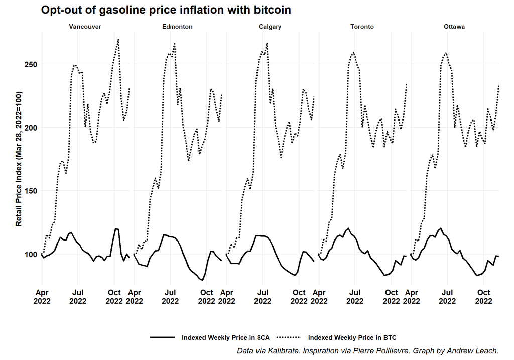

### Historic Diesel Prices

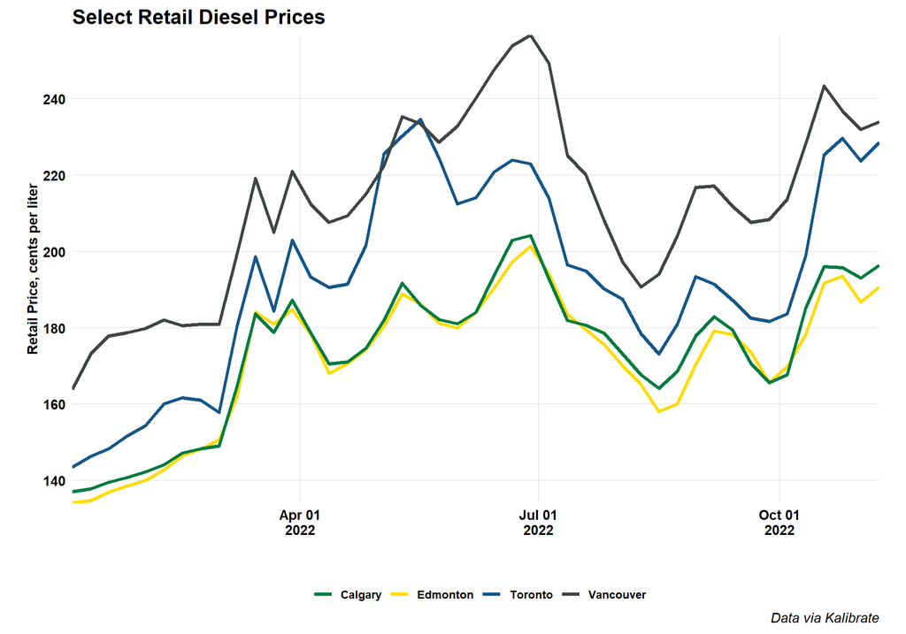

## Canadian Refinery Runs

### Canadian Refinery Runs

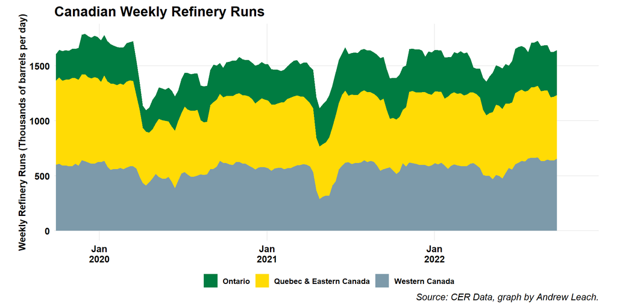

### Western Canada Refinery Runs

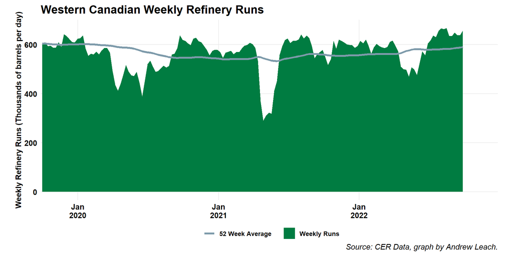